# SUPERVISED LEARNING PROJECT

# PART - A

• DOMAIN: Medical

• CONTEXT: Medical research university X is undergoing a deep research on patients with certain conditions. University has an internal AI team.Due to confidentiality the patient’s details and the conditions are masked by the client by providing different datasets to the AI team for developing a AIML model which can predict the condition of the patient depending on the received test results.

• DATA DESCRIPTION: The data consists of biomechanics features of the patients according to their current conditions. Each patient is represented in the data set by six biomechanics attributes derived from the shape and orientation of the condition to their body part.

• PROJECT OBJECTIVE: To Demonstrate the ability to fetch, process and leverage data to generate useful predictions by training Supervised Learning algorithms

## Part 1. 1 a - Read all the 3 CSV files as DataFrame and store them into 3 separate variables.

```python
import numpy as np
import pandas as pd
import matplotlib.pyplot as plt
import seaborn as sns
%matplotlib inline
import warnings
warnings.filterwarnings('ignore')
```

```python
df1=pd.read_csv('Normal.csv')
df1.head()
```

|  | P_incidence | P_tilt | L_angle | S_slope | P_radius | S_Degree | Class |
| --- | --- | --- | --- | --- | --- | --- | --- |
| 0 | 38.505273 | 16.964297 | 35.112814 | 21.540976 | 127.632875 | 7.986683 | Normal |
| 1 | 54.920858 | 18.968430 | 51.601455 | 35.952428 | 125.846646 | 2.001642 | Normal |
| 2 | 44.362490 | 8.945435 | 46.902096 | 35.417055 | 129.220682 | 4.994195 | Normal |
| 3 | 48.318931 | 17.452121 | 48.000000 | 30.866809 | 128.980308 | -0.910941 | Normal |
| 4 | 45.701789 | 10.659859 | 42.577846 | 35.041929 | 130.178314 | -3.388910 | Normal |

```python
df2=pd.read_csv('Type_H.csv')
df2.head()
```

|  | P_incidence | P_tilt | L_angle | S_slope | P_radius | S_Degree | Class |
| --- | --- | --- | --- | --- | --- | --- | --- |
| 0 | 63.027817 | 22.552586 | 39.609117 | 40.475232 | 98.672917 | -0.254400 | Type_H |
| 1 | 39.056951 | 10.060991 | 25.015378 | 28.995960 | 114.405425 | 4.564259 | Type_H |
| 2 | 68.832021 | 22.218482 | 50.092194 | 46.613539 | 105.985135 | -3.530317 | Type_H |
| 3 | 69.297008 | 24.652878 | 44.311238 | 44.644130 | 101.868495 | 11.211523 | Type_H |
| 4 | 49.712859 | 9.652075 | 28.317406 | 40.060784 | 108.168725 | 7.918501 | Type_H |

```python
df3=pd.read_csv('Type_S.csv')
df3.head()
```

|  | P_incidence | P_tilt | L_angle | S_slope | P_radius | S_Degree | Class |
| --- | --- | --- | --- | --- | --- | --- | --- |
| 0 | 74.377678 | 32.053104 | 78.772013 | 42.324573 | 143.560690 | 56.125906 | Type_S |
| 1 | 89.680567 | 32.704435 | 83.130732 | 56.976132 | 129.955476 | 92.027277 | Type_S |
| 2 | 44.529051 | 9.433234 | 52.000000 | 35.095817 | 134.711772 | 29.106575 | Type_S |
| 3 | 77.690577 | 21.380645 | 64.429442 | 56.309932 | 114.818751 | 26.931841 | Type_S |
| 4 | 76.147212 | 21.936186 | 82.961502 | 54.211027 | 123.932010 | 10.431972 | Type_S |

## Part 1.1 b - Print Shape and columns of all the 3 DataFrames

```python
print(df1.shape)
```

```
(100, 7)
```

```python
print(df1.columns)
```

```
Index(['P_incidence', 'P_tilt', 'L_angle', 'S_slope', 'P_radius', 'S_Degree',
       'Class'],
      dtype='object')
```

```python
print(df2.shape)
```

```
(60, 7)
```

```python
print(df2.columns)
```

```
Index(['P_incidence', 'P_tilt', 'L_angle', 'S_slope', 'P_radius', 'S_Degree',
       'Class'],
      dtype='object')
```

```python
print(df3.shape)
```

```
(150, 7)
```

```python
print(df3.columns)
```

```
Index(['P_incidence', 'P_tilt', 'L_angle', 'S_slope', 'P_radius', 'S_Degree',
       'Class'],
      dtype='object')
```

## Part 1.1 c - Compare Column names of all the 3 DataFrames and clearly write observations

```python
print(df1.columns)
```

```
Index(['P_incidence', 'P_tilt', 'L_angle', 'S_slope', 'P_radius', 'S_Degree',
       'Class'],
      dtype='object')
```

```python
print(df2.columns)
```

```
Index(['P_incidence', 'P_tilt', 'L_angle', 'S_slope', 'P_radius', 'S_Degree',
       'Class'],
      dtype='object')
```

```python
print(df3.columns)
```

```
Index(['P_incidence', 'P_tilt', 'L_angle', 'S_slope', 'P_radius', 'S_Degree',
       'Class'],
      dtype='object')
```

- In all three data frames have same column names

## Part 1.1 d - Print DataTypes of all the 3 DataFrames.

```python
print(df1.dtypes)
```

```
P_incidence    float64
P_tilt         float64
L_angle        float64
S_slope        float64
P_radius       float64
S_Degree       float64
Class           object
dtype: object
```

```python
print(df2.dtypes)
```

```
P_incidence    float64
P_tilt         float64
L_angle        float64
S_slope        float64
P_radius       float64
S_Degree       float64
Class           object
dtype: object
```

```python
print(df3.dtypes)
```

```
P_incidence    float64
P_tilt         float64
L_angle        float64
S_slope        float64
P_radius       float64
S_Degree       float64
Class           object
dtype: object
```

## Part 1.1 e - Observe and share variation in ‘Class’ feature of all the 3 DataFrames

```python
print(df1.Class.value_counts())
```

```
Normal    73
Nrmal     27
Name: Class, dtype: int64
```

```python
print(df2.Class.value_counts())
```

```
Type_H    37
type_h    23
Name: Class, dtype: int64
```

```python
print(df3.Class.value_counts())
```

```
Type_S    133
tp_s       17
Name: Class, dtype: int64
```

- In Normal (df1) has Class column with rows named as 'Normal' and 'Nrml'
- In Type_H (df2) has Class column with rows named as 'Type_H' and 'type_h'
- In Type_S (df3) has Class column with rows named as 'Type_S' and 'tp_s'

## Part 1.2 a - Unify all the variations in ‘Class’ feature for all the 3 DataFrames

```python
df1.Class=df1.Class.replace('Nrmal',df1.Class.mode()[0])
print(df1.Class.value_counts())
```

```
Normal    100
Name: Class, dtype: int64
```

```python
df2.Class=df2.Class.replace('type_h',df2.Class.mode()[0])
print(df2.Class.value_counts())
```

```
Type_H    60
Name: Class, dtype: int64
```

```python
df3.Class=df3.Class.replace('tp_s',df3.Class.mode()[0])
print(df3.Class.value_counts())
```

```
Type_S    150
Name: Class, dtype: int64
```

## Part 1.2 b - Combine all the 3 DataFrames to form a single DataFrame

```python
df_f=pd.concat([df1,df2,df3],axis=0)  #combining data frames to a single dataframe
df_f.tail()
```

|  | P_incidence | P_tilt | L_angle | S_slope | P_radius | S_Degree | Class |
| --- | --- | --- | --- | --- | --- | --- | --- |
| 145 | 80.111572 | 33.942432 | 85.101608 | 46.169139 | 125.593624 | 100.292107 | Type_S |
| 146 | 95.480229 | 46.550053 | 59.000000 | 48.930176 | 96.683903 | 77.283072 | Type_S |
| 147 | 74.094731 | 18.823727 | 76.032156 | 55.271004 | 128.405731 | 73.388216 | Type_S |
| 148 | 87.679087 | 20.365613 | 93.822416 | 67.313473 | 120.944829 | 76.730629 | Type_S |
| 149 | 48.259920 | 16.417462 | 36.329137 | 31.842457 | 94.882336 | 28.343799 | Type_S |

```python
df_f.reset_index(drop=True,inplace=True)   #reset index and droping original index
```

```python
df_f.tail()        # checking index
```

|  | P_incidence | P_tilt | L_angle | S_slope | P_radius | S_Degree | Class |
| --- | --- | --- | --- | --- | --- | --- | --- |
| 305 | 80.111572 | 33.942432 | 85.101608 | 46.169139 | 125.593624 | 100.292107 | Type_S |
| 306 | 95.480229 | 46.550053 | 59.000000 | 48.930176 | 96.683903 | 77.283072 | Type_S |
| 307 | 74.094731 | 18.823727 | 76.032156 | 55.271004 | 128.405731 | 73.388216 | Type_S |
| 308 | 87.679087 | 20.365613 | 93.822416 | 67.313473 | 120.944829 | 76.730629 | Type_S |
| 309 | 48.259920 | 16.417462 | 36.329137 | 31.842457 | 94.882336 | 28.343799 | Type_S |

```python
df_f.info()
```

```
<class 'pandas.core.frame.DataFrame'>
RangeIndex: 310 entries, 0 to 309
Data columns (total 7 columns):
 #   Column       Non-Null Count  Dtype
---  ------       --------------  -----
 0   P_incidence  310 non-null    float64
 1   P_tilt       310 non-null    float64
 2   L_angle      310 non-null    float64
 3   S_slope      310 non-null    float64
 4   P_radius     310 non-null    float64
 5   S_Degree     310 non-null    float64
 6   Class        310 non-null    object
dtypes: float64(6), object(1)
memory usage: 17.1+ KB
```

```python
print(df_f.shape)
```

```
(310, 7)
```

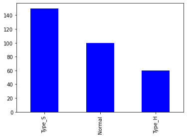

```python
df_f.Class.value_counts().plot(kind='bar',color='b'); # checking Class values distributions
```

## Part 1.2 c - Print 5 random samples of this DataFrame

```python
df_f.sample(5)
```

|  | P_incidence | P_tilt | L_angle | S_slope | P_radius | S_Degree | Class |
| --- | --- | --- | --- | --- | --- | --- | --- |
| 266 | 56.991404 | 6.874089 | 57.009005 | 50.117315 | 109.978045 | 36.810111 | Type_S |
| 259 | 64.274818 | 12.508643 | 68.702377 | 51.766175 | 95.252454 | 39.409826 | Type_S |
| 115 | 44.318907 | 12.537992 | 36.098763 | 31.780915 | 124.115836 | 5.415825 | Type_H |
| 20 | 65.611802 | 23.137919 | 62.582179 | 42.473883 | 124.128001 | -4.083298 | Normal |
| 73 | 48.995958 | 13.113820 | 51.873520 | 35.882137 | 126.398188 | 0.535472 | Normal |

## Part 1.2 d - Print Feature-wise percentage of Null values

```python
print(df_f.isnull().sum()/len(df_f.index)) # percentage of Null values
```

```
P_incidence    0.0
P_tilt         0.0
L_angle        0.0
S_slope        0.0
P_radius       0.0
S_Degree       0.0
Class          0.0
dtype: float64
```

- there is no Null values existed in our Dataframe

## Part 1.2 e - Check 5-point summary of the new DataFrame

```python
df_f.describe().T     # chceking five point summary
```

|  | count | mean | std | min | 25% | 50% | 75% | max |
| --- | --- | --- | --- | --- | --- | --- | --- | --- |
| P_incidence | 310.0 | 60.496653 | 17.236520 | 26.147921 | 46.430294 | 58.691038 | 72.877696 | 129.834041 |
| P_tilt | 310.0 | 17.542822 | 10.008330 | -6.554948 | 10.667069 | 16.357689 | 22.120395 | 49.431864 |
| L_angle | 310.0 | 51.930930 | 18.554064 | 14.000000 | 37.000000 | 49.562398 | 63.000000 | 125.742385 |
| S_slope | 310.0 | 42.953831 | 13.423102 | 13.366931 | 33.347122 | 42.404912 | 52.695888 | 121.429566 |
| P_radius | 310.0 | 117.920655 | 13.317377 | 70.082575 | 110.709196 | 118.268178 | 125.467674 | 163.071041 |
| S_Degree | 310.0 | 26.296694 | 37.559027 | -11.058179 | 1.603727 | 11.767934 | 41.287352 | 418.543082 |

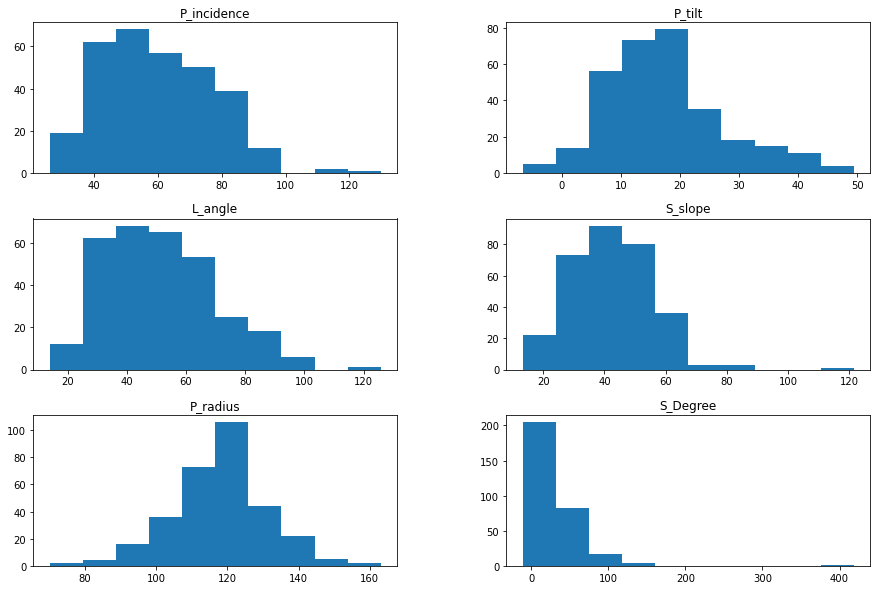

```python
df_f.hist(figsize=(15,10),grid=False);
```

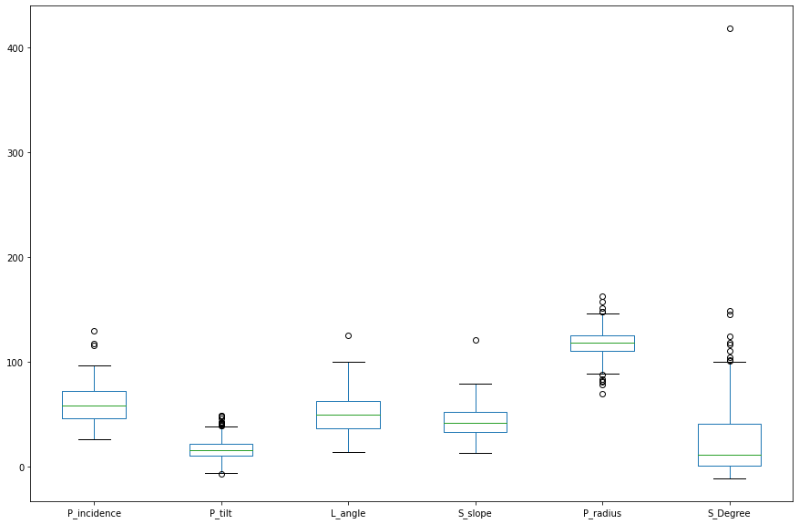

```python
df_f.boxplot(figsize=(15,10),grid=False);
```

- Except S_Degree feature remaining all features looking like normal distriuted (Mean ~ median)

## Part 1.3 a - Visualize a heatmap to understand correlation between all features

```python
df_f.corr()
```

|  | P_incidence | P_tilt | L_angle | S_slope | P_radius | S_Degree |
| --- | --- | --- | --- | --- | --- | --- |
| P_incidence | 1.000000 | 0.629199 | 0.717282 | 0.814960 | -0.247467 | 0.638743 |
| P_tilt | 0.629199 | 1.000000 | 0.432764 | 0.062345 | 0.032668 | 0.397862 |
| L_angle | 0.717282 | 0.432764 | 1.000000 | 0.598387 | -0.080344 | 0.533667 |
| S_slope | 0.814960 | 0.062345 | 0.598387 | 1.000000 | -0.342128 | 0.523557 |
| P_radius | -0.247467 | 0.032668 | -0.080344 | -0.342128 | 1.000000 | -0.026065 |
| S_Degree | 0.638743 | 0.397862 | 0.533667 | 0.523557 | -0.026065 | 1.000000 |

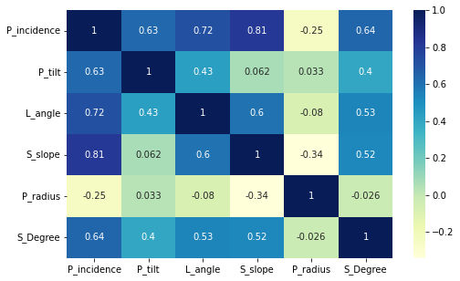

```python
plt.figure(figsize=(8,5))
sns.heatmap(df_f.corr(),annot=True,cmap='YlGnBu')
plt.yticks(rotation='0');
```

## Part 1.3 b - Share insights on correlation

- P_incidnce correlation with S_degree(0.64) , S_slope(0.81) ,L_angle(0.72) , P_tilt(0.63)

## Part 1.3 c - Visualize a pairplot with 3 classes distinguished by colors and share insights

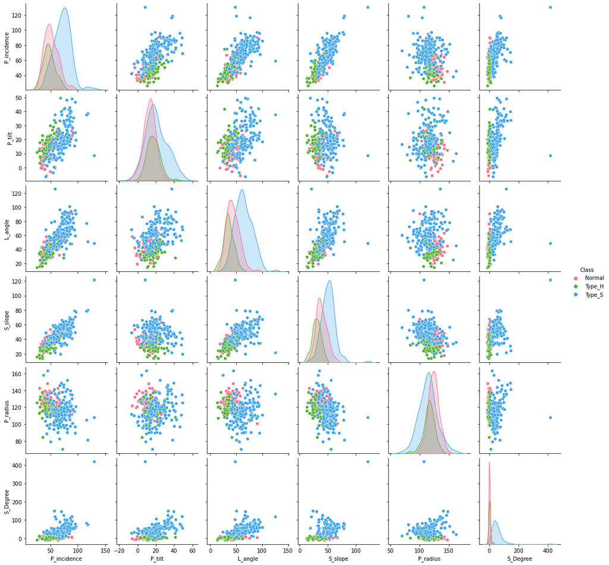

```python
sns.pairplot(df_f,palette='husl',hue='Class');
```

- P_incidence has positive relation with S_slope,L_angle,P_tilt
- L_angle has some positive relation with S_slope

## Part 1.3 d - Visualize a jointplot for ‘P_incidence’ and ‘S_slope’ and share insights

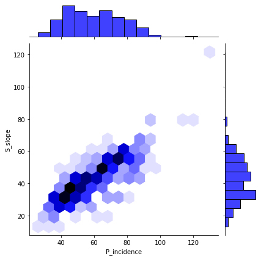

```python
sns.jointplot(data=df_f,x='P_incidence',y='S_slope',kind="hex",color='b');
```

- P_incidence and S_slope both are looking like normal distribution
- Both are having a positive relation between them

## Part 1.3 e - Visualize a boxplot to check distribution of the features and share insights.

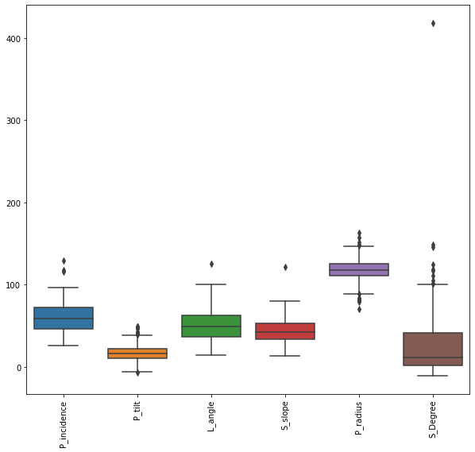

```python
plt.figure(figsize=(10,9))
sns.boxplot(data=df_f)
plt.xticks(rotation='90');
```

- In above Box plot all the features except S_Degree, looking like mean and median are equal and follows normal distributions
- all features having the outliers especially S_Degree column having the outlier above 400
- S_Degree column is a right skewed distribution

```python
df_f[['P_incidence','P_tilt','L_angle', 'S_slope', 'P_radius']].describe().T
```

|  | count | mean | std | min | 25% | 50% | 75% | max |
| --- | --- | --- | --- | --- | --- | --- | --- | --- |
| P_incidence | 310.0 | 60.496653 | 17.236520 | 26.147921 | 46.430294 | 58.691038 | 72.877696 | 129.834041 |
| P_tilt | 310.0 | 17.542822 | 10.008330 | -6.554948 | 10.667069 | 16.357689 | 22.120395 | 49.431864 |
| L_angle | 310.0 | 51.930930 | 18.554064 | 14.000000 | 37.000000 | 49.562398 | 63.000000 | 125.742385 |
| S_slope | 310.0 | 42.953831 | 13.423102 | 13.366931 | 33.347122 | 42.404912 | 52.695888 | 121.429566 |
| P_radius | 310.0 | 117.920655 | 13.317377 | 70.082575 | 110.709196 | 118.268178 | 125.467674 | 163.071041 |

```python
print(df_f['S_Degree'].describe())
```

```
count    310.000000
mean      26.296694
std       37.559027
min      -11.058179
25%        1.603727
50%       11.767934
75%       41.287352
max      418.543082
Name: S_Degree, dtype: float64
```

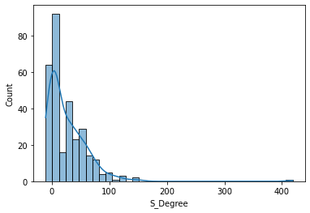

```python
sns.histplot(data=df_f,x='S_Degree',kde=True);
```

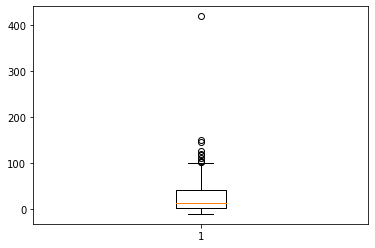

```python
plot=plt.boxplot(df_f['S_Degree']);
```

```python
upper_fence=plot['caps'][1].get_data()[1][1]
print(upper_fence)
```

```
100.2921068
```

```python
num_of_outliers=(df_f['S_Degree']>upper_fence).sum()
print(num_of_outliers)
```

```
10
```

## Part 1.4 a - Split data into X and Y.

```python
df_f['Class']=df_f['Class'].astype('object')
print(df_f.dtypes)
```

```
P_incidence    float64
P_tilt         float64
L_angle        float64
S_slope        float64
P_radius       float64
S_Degree       float64
Class           object
dtype: object
```

```python
x=df_f.drop('Class',axis=1)     # definining independent(x) and dependent(y) variables
y=df_f['Class']
print(x.shape)
print(y.shape)
```

```
(310, 6)
(310,)
```

```python
from scipy.stats import zscore
X=x.apply(zscore)             # applying Z score to normalise the x columns
X.head()
```

|  | P_incidence | P_tilt | L_angle | S_slope | P_radius | S_Degree |
| --- | --- | --- | --- | --- | --- | --- |
| 0 | -1.277922 | -0.057898 | -0.907904 | -1.597803 | 0.730468 | -0.488288 |
| 1 | -0.324010 | 0.142672 | -0.017786 | -0.522437 | 0.596124 | -0.647896 |
| 2 | -0.937559 | -0.860412 | -0.271475 | -0.562386 | 0.849889 | -0.568091 |
| 3 | -0.707649 | -0.009077 | -0.212206 | -0.901920 | 0.831811 | -0.725568 |
| 4 | -0.859732 | -0.688835 | -0.504914 | -0.590377 | 0.921914 | -0.791650 |

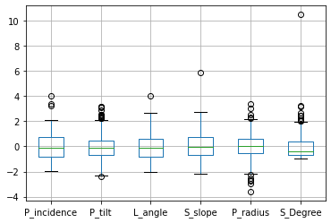

```python
X.boxplot();
```

```python
print(y.value_counts())
```

```
Type_S    150
Normal    100
Type_H     60
Name: Class, dtype: int64
```

- The classes are imbalanced

## Part 1.4 b - Split data into train and test with 80:20 proportion

```python
import sklearn
from sklearn.model_selection import train_test_split

x_train,x_test,y_train,y_test=train_test_split(X,y,test_size=0.20,random_state=1)
```

```python
print(x_train.shape)
print(x_test.shape)
print(y_train.shape)
print(y_test.shape)
```

```
(248, 6)
(62, 6)
(248,)
(62,)
```

```python
print(y_train.value_counts())
```

```
Type_S    117
Normal     82
Type_H     49
Name: Class, dtype: int64
```

```python
x_train.info()
```

```
<class 'pandas.core.frame.DataFrame'>
Int64Index: 248 entries, 307 to 37
Data columns (total 6 columns):
 #   Column       Non-Null Count  Dtype
---  ------       --------------  -----
 0   P_incidence  248 non-null    float64
 1   P_tilt       248 non-null    float64
 2   L_angle      248 non-null    float64
 3   S_slope      248 non-null    float64
 4   P_radius     248 non-null    float64
 5   S_Degree     248 non-null    float64
dtypes: float64(6)
memory usage: 13.6 KB
```

## Part 1.4 c - Train a Supervised Learning Classification base model using KNN classifier

```python
from sklearn.neighbors import KNeighborsClassifier
knn = KNeighborsClassifier()
```

```python
knn.fit(x_train,y_train)
```

```
KNeighborsClassifier()
```

# Part 1.4 d - Print all the possible performance metrics for both train and test data

### Performance Metrics for Training set

```python
from sklearn.metrics import accuracy_score,confusion_matrix,classification_report

y_pred_tr=knn.predict(x_train)
print(" The accuracy score of training set : %1.2f "   %accuracy_score(y_train,y_pred_tr))    # checking train score
```

```
 The accuracy score of training set : 0.85
```

```python
print(classification_report(y_train,y_pred_tr))
```

```
              precision    recall  f1-score   support

      Normal       0.79      0.78      0.79        82
      Type_H       0.70      0.78      0.74        49
      Type_S       0.96      0.92      0.94       117

    accuracy                           0.85       248
   macro avg       0.82      0.83      0.82       248
weighted avg       0.85      0.85      0.85       248
```

```python
from sklearn.metrics import precision_score,recall_score,f1_score
print("the precision score for training set : %1.2f " %precision_score(y_train,y_pred_tr,average='macro'))
print("the Recall score for training set : %1.2f  " %recall_score(y_train,y_pred_tr,average='macro'))
print("the f1-score for training set : %1.2f " %f1_score(y_train,y_pred_tr,average='macro'))
```

```
the precision score for training set : 0.82
the Recall score for training set : 0.83
the f1-score for training set : 0.82
```

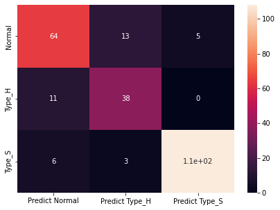

```python
cm_tr = confusion_matrix(y_train,y_pred_tr)
df_cm = pd.DataFrame(cm_tr, index = [i for i in ['Normal','Type_H ','Type_S']],
                  columns = [i for i in ["Predict Normal","Predict Type_H",'Predict Type_S']])
plt.figure(figsize = (7,5))
sns.heatmap(df_cm, annot=True);
```

### Performance Metrics for Testing set

```python
y_pred_tst=knn.predict(x_test)
print( "the accuracy score for Testing set : %1.2f " %accuracy_score(y_test,y_pred_tst))  # checking test score
```

```
the accuracy score for Testing set : 0.73
```

```python
print(classification_report(y_test,y_pred_tst))
```

```
              precision    recall  f1-score   support

      Normal       0.57      0.67      0.62        18
      Type_H       0.64      0.64      0.64        11
      Type_S       0.87      0.79      0.83        33

    accuracy                           0.73        62
   macro avg       0.69      0.70      0.69        62
weighted avg       0.74      0.73      0.73        62
```

```python
print("the precision score for Testing set : %1.2f " %precision_score(y_test,y_pred_tst,average='macro'))
print("the Recall score for Testing set : %1.2f  " %recall_score(y_test,y_pred_tst,average='macro'))
print("the f1-score for Testing set : %1.2f " %f1_score(y_test,y_pred_tst,average='macro'))
```

```
the precision score for Testing set : 0.69
the Recall score for Testing set : 0.70
the f1-score for Testing set : 0.69
```

```python
cm=confusion_matrix(y_test,y_pred_tst)
cm
```

```
array([[12,  2,  4],
       [ 4,  7,  0],
       [ 5,  2, 26]], dtype=int64)
```

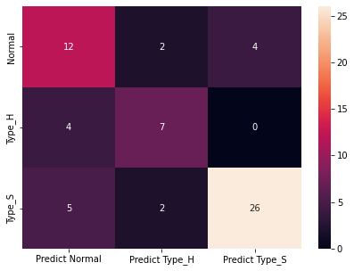

```python
cm_tst = confusion_matrix(y_test,y_pred_tst)
df_cm_tst = pd.DataFrame(cm_tst, index = [i for i in ['Normal','Type_H ','Type_S']],
                  columns = [i for i in ["Predict Normal","Predict Type_H",'Predict Type_S']])
plt.figure(figsize = (7,5))
sns.heatmap(df_cm_tst, annot=True);
```

## Part 1.5 a - Experiment with various parameters to improve performance of the base model

#### The n_neighbour parameter

```python
rang=np.arange(1,30)

ac_scores = []

# perform accuracy metrics for values from 1,2,3,....30
for k in rang:
    knn_a = KNeighborsClassifier(n_neighbors=k,)
    knn_a.fit(x_train, y_train)
    # predict the response
    y_pred = knn_a.predict(x_test)
    # evaluate accuracy
    scores = accuracy_score(y_test, y_pred)
    ac_scores.append(scores)
    print('for the k = {} value the testing  {}'.format(k,round(ac_scores[-1],2)))

# changing to misclassification error
MSE = [1 - x for x in ac_scores]

# determining best k
optimal_k = rang[MSE.index(min(MSE))]

print("The optimal number of neighbors is %d" % optimal_k)
```

```
for the k = 1 value the testing  0.82
for the k = 2 value the testing  0.74
for the k = 3 value the testing  0.71
for the k = 4 value the testing  0.68
for the k = 5 value the testing  0.73
for the k = 6 value the testing  0.71
for the k = 7 value the testing  0.76
for the k = 8 value the testing  0.74
for the k = 9 value the testing  0.74
for the k = 10 value the testing  0.71
for the k = 11 value the testing  0.71
for the k = 12 value the testing  0.71
for the k = 13 value the testing  0.71
for the k = 14 value the testing  0.73
for the k = 15 value the testing  0.74
for the k = 16 value the testing  0.73
for the k = 17 value the testing  0.76
for the k = 18 value the testing  0.76
for the k = 19 value the testing  0.76
for the k = 20 value the testing  0.76
for the k = 21 value the testing  0.76
for the k = 22 value the testing  0.76
for the k = 23 value the testing  0.76
for the k = 24 value the testing  0.76
for the k = 25 value the testing  0.74
for the k = 26 value the testing  0.76
for the k = 27 value the testing  0.76
for the k = 28 value the testing  0.76
for the k = 29 value the testing  0.76
The optimal number of neighbors is 1
```

```python
knn_n=KNeighborsClassifier(n_neighbors=optimal_k)
knn_n.fit(x_train,y_train)
print("The accuracy Score when n_neighbour is 1 : %1.2f " %knn_n.score(x_test,y_test))
```

```
The accuracy Score when n_neighbour is 1 : 0.82
```

```python
print(classification_report(y_test,knn_n.predict(x_test)))
```

```
              precision    recall  f1-score   support

      Normal       0.74      0.78      0.76        18
      Type_H       0.75      0.82      0.78        11
      Type_S       0.90      0.85      0.88        33

    accuracy                           0.82        62
   macro avg       0.80      0.81      0.80        62
weighted avg       0.83      0.82      0.82        62
```

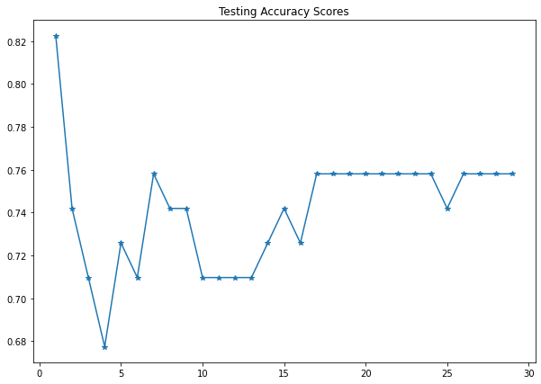

```python
plt.figure(figsize=(10,7))
plt.plot(rang,ac_scores,"*-")
plt.title("Testing Accuracy Scores");
```

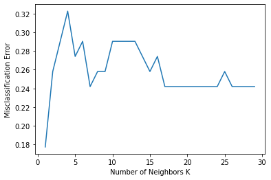

```python
plt.plot(rang, MSE)
plt.xlabel('Number of Neighbors K')
plt.ylabel('Misclassification Error')
plt.show()
```

### Weights parameter

```python
ac_scores_w = []
weights= ['uniform','distance']
for w in weights:
    knn_w = KNeighborsClassifier(weights=w)
    knn_w.fit(x_train, y_train)
    # predict the response
    y_pred_w = knn_w.predict(x_test)
    scores = accuracy_score(y_test, y_pred_w)
    ac_scores_w.append(scores)
    print('for the weights = {}  and testing  {}'.format(w,round(ac_scores[-1],2)))
```

```
for the weights = uniform  and testing  0.76
for the weights = distance  and testing  0.76
```

### When n_neighbor = 1 and weight = distance

```python
knn_w=KNeighborsClassifier(n_neighbors=1,weights='distance')
knn_w.fit(x_train,y_train)
print("The accuracy Score when n_neighbour is 1 and weights= distance is  : %1.2f " %knn_w.score(x_test,y_test))
```

```
The accuracy Score when n_neighbour is 1 and weights= distance is  : 0.82
```

When neighbors is one and weights is distance there is no change in the accuracy

### Algoritham parameter

```python
ac_scores = []
tr_scores = []
algor= ['auto','ball_tree','kd_tree','brute']
for a in algor:
    knn = KNeighborsClassifier(n_neighbors=1,algorithm=a)
    knn.fit(x_train, y_train)
    # predict the response
    y_pred = knn.predict(x_test)
    scores = accuracy_score(y_test, y_pred)
    ac_scores.append(scores)
    s = knn.score(x_train,y_train)
    tr_scores.append(s)
    print('for the algoritham =  {}  then the trainig  {}  and testing  {}'.format(a,round(tr_scores[-1],2),round(ac_scores[-1],2)))
```

```
for the algoritham =  auto  then the trainig  1.0  and testing  0.82
for the algoritham =  ball_tree  then the trainig  1.0  and testing  0.82
for the algoritham =  kd_tree  then the trainig  1.0  and testing  0.82
for the algoritham =  brute  then the trainig  1.0  and testing  0.82
```

- There is no change is observed in accuracy when algoritham is changes

### Metric parameter

```python
ac_scores = []
tr_scores = []
metric = ['minkowski','euclidean','manhattan']
for a in metric:
    knn = KNeighborsClassifier(n_neighbors=1,metric=a)
    knn.fit(x_train, y_train)
    # predict the response
    y_pred = knn.predict(x_test)
    scores = accuracy_score(y_test, y_pred)
    ac_scores.append(scores)
    s = knn.score(x_train,y_train)
    tr_scores.append(s)
    print('for the metric = {} value the trainig  {}  and testing  {}'.format(a,round(tr_scores[-1],2),round(ac_scores[-1],2)))
```

```
for the metric = minkowski value the trainig  1.0  and testing  0.82
for the metric = euclidean value the trainig  1.0  and testing  0.82
for the metric = manhattan value the trainig  1.0  and testing  0.74
```

```python
ac_scores = []
tr_scores = []
p = [1,2,3,4,5]
for a in p:
    knn = KNeighborsClassifier(n_neighbors=1,p=a)
    knn.fit(x_train, y_train)
    # predict the response
    y_pred = knn.predict(x_test)
    scores = accuracy_score(y_test, y_pred)
    ac_scores.append(scores)
    s = knn.score(x_train,y_train)
    tr_scores.append(s)
    print('for the p = {} value the trainig  {}  and testing  {}'.format(a,round(tr_scores[-1],2),round(ac_scores[-1],2)))
MSE = [1 - x for x in ac_scores]
M = [1 - x for x in tr_scores]

# determining best k
optimal_k = rang[MSE.index(min(MSE))]
opt_k = rang[M.index(min(M))]
print("The optimal number of p is %d" % optimal_k)
print("The optimal number of p is %d" % opt_k)
```

```
for the p = 1 value the trainig  1.0  and testing  0.74
for the p = 2 value the trainig  1.0  and testing  0.82
for the p = 3 value the trainig  1.0  and testing  0.85
for the p = 4 value the trainig  1.0  and testing  0.84
for the p = 5 value the trainig  1.0  and testing  0.82
The optimal number of p is 3
The optimal number of p is 1
```

- There is a change is observed in accuracy when p=3

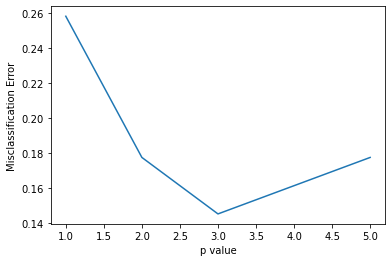

```python
plt.plot(p,MSE)
plt.xlabel('p value')
plt.ylabel('Misclassification Error')
plt.show()
```

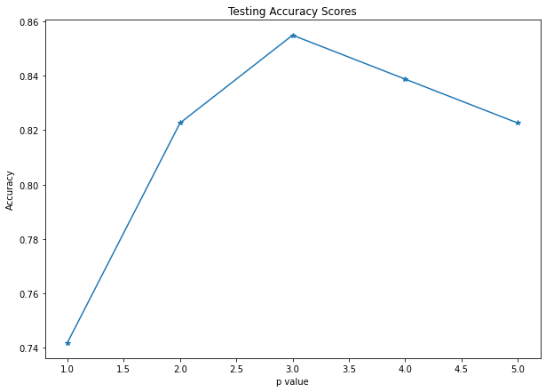

```python
plt.figure(figsize=(10,7))
plt.plot(p,ac_scores,"*-")
plt.title("Testing Accuracy Scores")
plt.xlabel("p value")
plt.ylabel("Accuracy");
```

```python
knn_p = KNeighborsClassifier(n_neighbors=1,p=3)
knn_p.fit(x_train, y_train)
print(classification_report(y_test,knn_p.predict(x_test)))
```

```
              precision    recall  f1-score   support

      Normal       0.79      0.83      0.81        18
      Type_H       0.75      0.82      0.78        11
      Type_S       0.94      0.88      0.91        33

    accuracy                           0.85        62
   macro avg       0.82      0.84      0.83        62
weighted avg       0.86      0.85      0.86        62
```

### Hyperparameters test with GridSerachCV

```python
from sklearn.model_selection import GridSearchCV
```

```python
space=dict()
space['n_neighbors'] = np.arange(1,30)
space['p'] = [1,2,3]

knn_grid=KNeighborsClassifier()

search_grid = GridSearchCV(knn_grid,space,cv=10)
```

```python
best_model=search_grid.fit(x_train,y_train)
```

```python
print(best_model.best_params_)
```

```
{'n_neighbors': 1, 'p': 2}
```

```python
print('best score %1.2f : '        %best_model.best_score_)
print('best hyper parameters :' ,  best_model.best_params_)
print('best hyper parameters :' ,  best_model.best_estimator_)
```

```
best score 0.82 :
best hyper parameters : {'n_neighbors': 1, 'p': 2}
best hyper parameters : KNeighborsClassifier(n_neighbors=1)
```

```python
knn_final=KNeighborsClassifier(p=2, n_neighbors=1)
knn_final.fit(x_train,y_train)
print(knn_final.score(x_test,y_test))
```

```
0.8225806451612904
```

# Part 1.5 b - Clearly showcase improvement in performance achieved

### Before Experiment with various parameters

```python
print("the Accuracy score for Testing set : %1.2f"    %accuracy_score(y_test,y_pred_tst))
print("the precision score for Testing set : %1.2f "  %precision_score(y_test,y_pred_tst,average='macro'))
print("the Recall score for Testing set : %1.2f  "    %recall_score(y_test,y_pred_tst,average='macro'))
print("the f1-score for Testing set : %1.2f "         %f1_score(y_test,y_pred_tst,average='macro'))
```

```
the Accuracy score for Testing set : 0.73
the precision score for Testing set : 0.69
the Recall score for Testing set : 0.70
the f1-score for Testing set : 0.69
```

### After Experiment with various parameters

```python
print("the Accuracy score for Testing set : %1.2f"    %accuracy_score(y_test,knn_p.predict(x_test)))
print("the precision score for Testing set : %1.2f "  %precision_score(y_test,knn_p.predict(x_test),average='macro'))
print("the Recall score for Testing set : %1.2f  "    %recall_score(y_test,knn_p.predict(x_test),average='macro'))
print("the f1-score for Testing set : %1.2f "         %f1_score(y_test,knn_p.predict(x_test),average='macro'))
```

```
the Accuracy score for Testing set : 0.85
the precision score for Testing set : 0.82
the Recall score for Testing set : 0.84
the f1-score for Testing set : 0.83
```

- A) Accuracy Score improved by 12 %
- B) Precision improved by 13 %
- C) Recall(True Positive Rate) improved by 14 %
- D) F1-Score improved by 14 %

## Part 1.5 c - Clearly state which parameters contributed most to improve model performance.

The Parameters which contributed to improve model performance

A) n_neighbours ( k value)

B) p value

# PART-B

• DOMAIN: Banking, Marketing

• CONTEXT: A bank X is on a massive digital transformation for all its departments. Bank has a growing customer base where majority of them are liability customers (depositors) vs borrowers (asset customers). The bank is interested in expanding the borrowers base rapidly to bring in more business via loan interests. A campaign that the bank ran in last quarter showed an average single digit conversion rate. Digital transformation being the core strength of the business strategy, marketing department wants to devise effective campaigns with better target marketing to increase the conversion ratio to double digit with same budget as per last campaign.

• DATA DICTIONARY:

1. Team: Team’s name
2. ID: Customer ID
3. Age: Customer’s approximate age.
4. CustomerSince: Customer of the bank since. [unit is masked]
5. HighestSpend: Customer’s highest spend so far in one transaction. [unit is masked]
6. ZipCode: Customer’s zip code.
7. HiddenScore: A score associated to the customer which is masked by the bank as an IP.
8. MonthlyAverageSpend: Customer’s monthly average spend so far. [unit is masked]
9. Level: A level associated to the customer which is masked by the bank as an IP.
10. Mortgage: Customer’s mortgage. [unit is masked]
11. Security: Customer’s security asset with the bank. [unit is masked]
12. FixedDepositAccount: Customer’s fixed deposit account with the bank. [unit is masked]
13. InternetBanking: if the customer uses internet banking.
14. CreditCard: if the customer uses bank’s credit card.
15. LoanOnCard: if the customer has a loan on credit card.

• PROJECT OBJECTIVE: Build a Machine Learning model to perform focused marketing by predicting the potential customers who will convert using the historical dataset.

## Part 2.1 a - Read both the Datasets ‘Data1’ and ‘Data 2’ as DataFrame and store them into two separate variables

```python
data1=pd.read_csv('Data1.csv')
data1.head()
```

|  | ID | Age | CustomerSince | HighestSpend | ZipCode | HiddenScore | MonthlyAverageSpend | Level |
| --- | --- | --- | --- | --- | --- | --- | --- | --- |
| 0 | 1 | 25 | 1 | 49 | 91107 | 4 | 1.6 | 1 |
| 1 | 2 | 45 | 19 | 34 | 90089 | 3 | 1.5 | 1 |
| 2 | 3 | 39 | 15 | 11 | 94720 | 1 | 1.0 | 1 |
| 3 | 4 | 35 | 9 | 100 | 94112 | 1 | 2.7 | 2 |
| 4 | 5 | 35 | 8 | 45 | 91330 | 4 | 1.0 | 2 |

```python
data2=pd.read_csv('Data2.csv')
data2.head()
```

|  | ID | Mortgage | Security | FixedDepositAccount | InternetBanking | CreditCard | LoanOnCard |
| --- | --- | --- | --- | --- | --- | --- | --- |
| 0 | 1 | 0 | 1 | 0 | 0 | 0 | NaN |
| 1 | 2 | 0 | 1 | 0 | 0 | 0 | NaN |
| 2 | 3 | 0 | 0 | 0 | 0 | 0 | NaN |
| 3 | 4 | 0 | 0 | 0 | 0 | 0 | NaN |
| 4 | 5 | 0 | 0 | 0 | 0 | 1 | NaN |

## Part 2.1 b - Print shape and Column Names and DataTypes of both the Dataframes.

```python
print(data1.shape)
print(data2.shape)
```

```
(5000, 8)
(5000, 7)
```

```python
print(data1.columns)
print(data2.columns)
```

```
Index(['ID', 'Age', 'CustomerSince', 'HighestSpend', 'ZipCode', 'HiddenScore',
       'MonthlyAverageSpend', 'Level'],
      dtype='object')
Index(['ID', 'Mortgage', 'Security', 'FixedDepositAccount', 'InternetBanking',
       'CreditCard', 'LoanOnCard'],
      dtype='object')
```

```python
data1.info()
```

```
<class 'pandas.core.frame.DataFrame'>
RangeIndex: 5000 entries, 0 to 4999
Data columns (total 8 columns):
 #   Column               Non-Null Count  Dtype
---  ------               --------------  -----
 0   ID                   5000 non-null   int64
 1   Age                  5000 non-null   int64
 2   CustomerSince        5000 non-null   int64
 3   HighestSpend         5000 non-null   int64
 4   ZipCode              5000 non-null   int64
 5   HiddenScore          5000 non-null   int64
 6   MonthlyAverageSpend  5000 non-null   float64
 7   Level                5000 non-null   int64
dtypes: float64(1), int64(7)
memory usage: 312.6 KB
```

```python
data2.info()
```

```
<class 'pandas.core.frame.DataFrame'>
RangeIndex: 5000 entries, 0 to 4999
Data columns (total 7 columns):
 #   Column               Non-Null Count  Dtype
---  ------               --------------  -----
 0   ID                   5000 non-null   int64
 1   Mortgage             5000 non-null   int64
 2   Security             5000 non-null   int64
 3   FixedDepositAccount  5000 non-null   int64
 4   InternetBanking      5000 non-null   int64
 5   CreditCard           5000 non-null   int64
 6   LoanOnCard           4980 non-null   float64
dtypes: float64(1), int64(6)
memory usage: 273.6 KB
```

- It seems to be data2 dataframe had 20 null values in LoanOnCard Column

## Part 2.1 c - Merge both the Dataframes on ‘ID’ feature to form a single DataFrame

```python
data=pd.merge(data1,data2,on='ID')     # merging the two datasets on ID Feature
data.head()
```

|  | ID | Age | CustomerSince | HighestSpend | ZipCode | HiddenScore | MonthlyAverageSpend | Level | Mortgage | Security | FixedDepositAccount | InternetBanking | CreditCard | LoanOnCard |
| --- | --- | --- | --- | --- | --- | --- | --- | --- | --- | --- | --- | --- | --- | --- |
| 0 | 1 | 25 | 1 | 49 | 91107 | 4 | 1.6 | 1 | 0 | 1 | 0 | 0 | 0 | NaN |
| 1 | 2 | 45 | 19 | 34 | 90089 | 3 | 1.5 | 1 | 0 | 1 | 0 | 0 | 0 | NaN |
| 2 | 3 | 39 | 15 | 11 | 94720 | 1 | 1.0 | 1 | 0 | 0 | 0 | 0 | 0 | NaN |
| 3 | 4 | 35 | 9 | 100 | 94112 | 1 | 2.7 | 2 | 0 | 0 | 0 | 0 | 0 | NaN |
| 4 | 5 | 35 | 8 | 45 | 91330 | 4 | 1.0 | 2 | 0 | 0 | 0 | 0 | 1 | NaN |

## Part 2.1 d - Change Datatype of below features to ‘Object’

### ‘CreditCard’, ‘InternetBanking’, ‘FixedDepositAccount’, ‘Security’, ‘Level’, ‘HiddenScore’.

```python
data[['InternetBanking','CreditCard','FixedDepositAccount','Security','Level','HiddenScore']] = data[['InternetBanking','CreditCard','FixedDepositAccount','Security','Level','HiddenScore']].astype('object')
```

```python
data.info()
```

```
<class 'pandas.core.frame.DataFrame'>
Int64Index: 5000 entries, 0 to 4999
Data columns (total 14 columns):
 #   Column               Non-Null Count  Dtype
---  ------               --------------  -----
 0   ID                   5000 non-null   int64
 1   Age                  5000 non-null   int64
 2   CustomerSince        5000 non-null   int64
 3   HighestSpend         5000 non-null   int64
 4   ZipCode              5000 non-null   int64
 5   HiddenScore          5000 non-null   object
 6   MonthlyAverageSpend  5000 non-null   float64
 7   Level                5000 non-null   object
 8   Mortgage             5000 non-null   int64
 9   Security             5000 non-null   object
 10  FixedDepositAccount  5000 non-null   object
 11  InternetBanking      5000 non-null   object
 12  CreditCard           5000 non-null   object
 13  LoanOnCard           4980 non-null   float64
dtypes: float64(2), int64(6), object(6)
memory usage: 585.9+ KB
```

```python
print(data.shape)
```

```
(5000, 14)
```

## Part 2.2 a - Visualize distribution of Target variable ‘LoanOnCard’ and clearly share insights

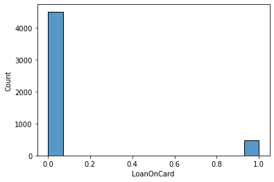

```python
sns.histplot(data=data,x='LoanOnCard');
```

```python
print(data.LoanOnCard.value_counts(normalize=True)*100)
```

```
0.0    90.361446
1.0     9.638554
Name: LoanOnCard, dtype: float64
```

- Its clearly shown that above 90 % data distributed as "0" in LoanOnCard Feature
- It means that the Target Variable classes are imbalanced

## Part 2.2 b - Check the percentage of missing values and impute if required

```python
print(data.isnull().sum())       # checking missing values in dataframe
```

```
ID                      0
Age                     0
CustomerSince           0
HighestSpend            0
ZipCode                 0
HiddenScore             0
MonthlyAverageSpend     0
Level                   0
Mortgage                0
Security                0
FixedDepositAccount     0
InternetBanking         0
CreditCard              0
LoanOnCard             20
dtype: int64
```

There are 20 Null values are observed in LoanOnCard feature

```python
print(data.LoanOnCard.unique())
```

```
[nan  1.  0.]
```

```python
print((data["LoanOnCard"].isna().sum())/(len(data)))  # checking percentage of missing values
```

```
0.004
```

- There are very less missing values percentage in our dataset
- Either we can drop or impute them

```python
data.LoanOnCard.fillna(data.LoanOnCard.mode()[0],inplace=True) # imputing missing values with mode
```

```python
data.isnull().sum()    # checking null values after imputing  with mode
```

```
ID                     0
Age                    0
CustomerSince          0
HighestSpend           0
ZipCode                0
HiddenScore            0
MonthlyAverageSpend    0
Level                  0
Mortgage               0
Security               0
FixedDepositAccount    0
InternetBanking        0
CreditCard             0
LoanOnCard             0
dtype: int64
```

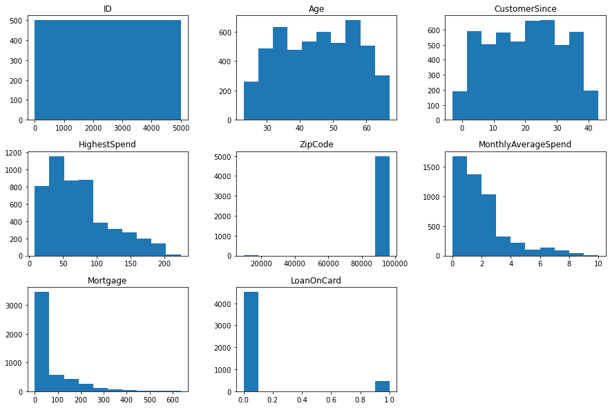

```python
data.hist(figsize=(15,10),grid=False);
```

- ID and Zipcode features having the whole distribution or at any one area.
- we don't have any use of those columns, we can drop them further.

## Part 2.2 c - Check for unexpected values in each categorical variable and impute with best suitable value.

```python
for i in data.columns:                             # The categorical columns names

    if data[i].dtypes=='object' :

        print(i)
```

```
HiddenScore
Level
Security
FixedDepositAccount
InternetBanking
CreditCard
```

```python
data_numerical_features = data.select_dtypes(include='number')   # Seperating numerical features
data_categorical_features = data.select_dtypes(include='object') # seperating categorical features
data_categorical_features.head()
```

|  | HiddenScore | Level | Security | FixedDepositAccount | InternetBanking | CreditCard |
| --- | --- | --- | --- | --- | --- | --- |
| 0 | 4 | 1 | 1 | 0 | 0 | 0 |
| 1 | 3 | 1 | 1 | 0 | 0 | 0 |
| 2 | 1 | 1 | 0 | 0 | 0 | 0 |
| 3 | 1 | 2 | 0 | 0 | 0 | 0 |
| 4 | 4 | 2 | 0 | 0 | 0 | 1 |

```python
# checking unexpected values in categorical columns by unique() method

for x in data_categorical_features.columns:
    print("{} column having unique values in {}".format(x,data_categorical_features[x].unique()))
```

```
HiddenScore column having unique values in [4 3 1 2]
Level column having unique values in [1 2 3]
Security column having unique values in [1 0]
FixedDepositAccount column having unique values in [0 1]
InternetBanking column having unique values in [0 1]
CreditCard column having unique values in [0 1]
```

## Part 2.3 a- Split data into X and Y

```python
data.drop(['ID','ZipCode'],axis=1,inplace=True)   # dropping ID and Zipcode
```

```python
data.dtypes
```

```
Age                      int64
CustomerSince            int64
HighestSpend             int64
HiddenScore             object
MonthlyAverageSpend    float64
Level                   object
Mortgage                 int64
Security                object
FixedDepositAccount     object
InternetBanking         object
CreditCard              object
LoanOnCard             float64
dtype: object
```

```python
data.head()
```

|  | Age | CustomerSince | HighestSpend | HiddenScore | MonthlyAverageSpend | Level | Mortgage | Security | FixedDepositAccount | InternetBanking | CreditCard | LoanOnCard |
| --- | --- | --- | --- | --- | --- | --- | --- | --- | --- | --- | --- | --- |
| 0 | 25 | 1 | 49 | 4 | 1.6 | 1 | 0 | 1 | 0 | 0 | 0 | 0.0 |
| 1 | 45 | 19 | 34 | 3 | 1.5 | 1 | 0 | 1 | 0 | 0 | 0 | 0.0 |
| 2 | 39 | 15 | 11 | 1 | 1.0 | 1 | 0 | 0 | 0 | 0 | 0 | 0.0 |
| 3 | 35 | 9 | 100 | 1 | 2.7 | 2 | 0 | 0 | 0 | 0 | 0 | 0.0 |
| 4 | 35 | 8 | 45 | 4 | 1.0 | 2 | 0 | 0 | 0 | 0 | 1 | 0.0 |

```python
print(data.columns)
```

```
Index(['Age', 'CustomerSince', 'HighestSpend', 'HiddenScore',
       'MonthlyAverageSpend', 'Level', 'Mortgage', 'Security',
       'FixedDepositAccount', 'InternetBanking', 'CreditCard', 'LoanOnCard'],
      dtype='object')
```

```python
# splitting our data into dependent and independent sets

X=data.drop('LoanOnCard',axis=1)
Y=data['LoanOnCard']
X.head()
```

|  | Age | CustomerSince | HighestSpend | HiddenScore | MonthlyAverageSpend | Level | Mortgage | Security | FixedDepositAccount | InternetBanking | CreditCard |
| --- | --- | --- | --- | --- | --- | --- | --- | --- | --- | --- | --- |
| 0 | 25 | 1 | 49 | 4 | 1.6 | 1 | 0 | 1 | 0 | 0 | 0 |
| 1 | 45 | 19 | 34 | 3 | 1.5 | 1 | 0 | 1 | 0 | 0 | 0 |
| 2 | 39 | 15 | 11 | 1 | 1.0 | 1 | 0 | 0 | 0 | 0 | 0 |
| 3 | 35 | 9 | 100 | 1 | 2.7 | 2 | 0 | 0 | 0 | 0 | 0 |
| 4 | 35 | 8 | 45 | 4 | 1.0 | 2 | 0 | 0 | 0 | 0 | 1 |

```python
print(X.shape)
print(Y.shape)
```

```
(5000, 11)
(5000,)
```

```python
# converting categorical features into numerical by creating dummies
X=pd.get_dummies(X,drop_first=True,columns=['HiddenScore','Level','Security','FixedDepositAccount','InternetBanking','CreditCard'])
```

```python
print(X.columns)
```

```
Index(['Age', 'CustomerSince', 'HighestSpend', 'MonthlyAverageSpend',
       'Mortgage', 'HiddenScore_2', 'HiddenScore_3', 'HiddenScore_4',
       'Level_2', 'Level_3', 'Security_1', 'FixedDepositAccount_1',
       'InternetBanking_1', 'CreditCard_1'],
      dtype='object')
```

```python
X.sample(10)
```

|  | Age | CustomerSince | HighestSpend | MonthlyAverageSpend | Mortgage | HiddenScore_2 | HiddenScore_3 | HiddenScore_4 | Level_2 | Level_3 | Security_1 | FixedDepositAccount_1 | InternetBanking_1 | CreditCard_1 |
| --- | --- | --- | --- | --- | --- | --- | --- | --- | --- | --- | --- | --- | --- | --- |
| 238 | 57 | 32 | 28 | 0.2 | 0 | 0 | 1 | 0 | 0 | 0 | 0 | 0 | 1 | 1 |
| 4723 | 39 | 15 | 125 | 3.5 | 0 | 0 | 0 | 0 | 0 | 0 | 0 | 0 | 1 | 1 |
| 935 | 46 | 20 | 131 | 5.7 | 256 | 0 | 0 | 0 | 0 | 0 | 0 | 0 | 0 | 1 |
| 1734 | 35 | 10 | 79 | 2.1 | 182 | 0 | 0 | 1 | 0 | 1 | 0 | 0 | 1 | 0 |
| 1702 | 56 | 30 | 122 | 0.5 | 0 | 1 | 0 | 0 | 0 | 0 | 0 | 0 | 0 | 1 |
| 4658 | 36 | 11 | 69 | 2.1 | 0 | 0 | 0 | 1 | 0 | 1 | 0 | 0 | 1 | 1 |
| 28 | 56 | 30 | 48 | 2.2 | 0 | 0 | 0 | 0 | 0 | 1 | 0 | 0 | 1 | 1 |
| 2018 | 63 | 39 | 160 | 2.1 | 0 | 1 | 0 | 0 | 0 | 0 | 0 | 0 | 1 | 1 |
| 2244 | 57 | 31 | 53 | 0.8 | 120 | 0 | 0 | 0 | 1 | 0 | 0 | 0 | 0 | 0 |
| 3202 | 30 | 4 | 25 | 0.3 | 0 | 1 | 0 | 0 | 0 | 0 | 1 | 0 | 1 | 0 |

```python
X.head()
```

|  | Age | CustomerSince | HighestSpend | MonthlyAverageSpend | Mortgage | HiddenScore_2 | HiddenScore_3 | HiddenScore_4 | Level_2 | Level_3 | Security_1 | FixedDepositAccount_1 | InternetBanking_1 | CreditCard_1 |
| --- | --- | --- | --- | --- | --- | --- | --- | --- | --- | --- | --- | --- | --- | --- |
| 0 | 25 | 1 | 49 | 1.6 | 0 | 0 | 0 | 1 | 0 | 0 | 1 | 0 | 0 | 0 |
| 1 | 45 | 19 | 34 | 1.5 | 0 | 0 | 1 | 0 | 0 | 0 | 1 | 0 | 0 | 0 |
| 2 | 39 | 15 | 11 | 1.0 | 0 | 0 | 0 | 0 | 0 | 0 | 0 | 0 | 0 | 0 |
| 3 | 35 | 9 | 100 | 2.7 | 0 | 0 | 0 | 0 | 1 | 0 | 0 | 0 | 0 | 0 |
| 4 | 35 | 8 | 45 | 1.0 | 0 | 0 | 0 | 1 | 1 | 0 | 0 | 0 | 0 | 1 |

```python
print(X.shape)
```

```
(5000, 14)
```

```python
Y=Y.astype('category')    # converting our target feature into category type
```

## Part 2.3 b - Split data into train and test. Keep 25% data reserved for testing

```python
x_train,x_test,y_train,y_test = train_test_split(X,Y,test_size=0.25,random_state=42)
```

```python
print(x_train.shape[0]/(len(X)))
print(x_test.shape[0]/len(X))
```

```
0.75
0.25
```

```python
x_train.head()
```

|  | Age | CustomerSince | HighestSpend | MonthlyAverageSpend | Mortgage | HiddenScore_2 | HiddenScore_3 | HiddenScore_4 | Level_2 | Level_3 | Security_1 | FixedDepositAccount_1 | InternetBanking_1 | CreditCard_1 |
| --- | --- | --- | --- | --- | --- | --- | --- | --- | --- | --- | --- | --- | --- | --- |
| 4884 | 60 | 34 | 50 | 2.2 | 0 | 0 | 1 | 0 | 0 | 1 | 0 | 0 | 1 | 1 |
| 3163 | 51 | 27 | 52 | 1.0 | 0 | 1 | 0 | 0 | 0 | 1 | 0 | 0 | 0 | 0 |
| 490 | 34 | 10 | 90 | 2.7 | 0 | 1 | 0 | 0 | 0 | 0 | 0 | 0 | 1 | 0 |
| 862 | 50 | 23 | 15 | 1.0 | 101 | 1 | 0 | 0 | 1 | 0 | 0 | 0 | 0 | 0 |
| 1740 | 45 | 20 | 59 | 2.4 | 0 | 0 | 0 | 0 | 0 | 0 | 1 | 1 | 1 | 0 |

```python
print(x_train.shape)
print(y_train.shape)
```

```
(3750, 14)
(3750,)
```

## Part 2.3 c - Train a Supervised Learning Classification base model - Logistic Regression

```python
from sklearn.linear_model import LogisticRegression
```

```python
model=LogisticRegression(max_iter=5000)
model.fit(x_train, y_train)
y_pred = model.predict(x_test)
```

## Part 2.3 d - Print evaluation metrics for the model and clearly share insights.

```python
from sklearn.metrics import confusion_matrix, accuracy_score, classification_report

y_pred_tr = model.predict(x_train)
print('Training accuracy score :  %1.4f'   %accuracy_score(y_train,y_pred_tr))
```

```
Training accuracy score :  0.9579
```

```python
y_pred_tst = model.predict(x_test)
print('Testing accuracy score  :  %1.4f'   %accuracy_score(y_test,y_pred_tst))
```

```
Testing accuracy score  :  0.9632
```

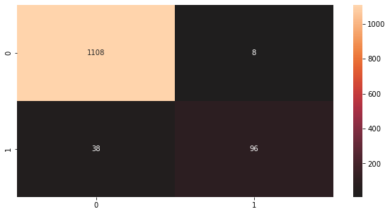

```python
plt.figure(figsize=(10,5))
cm = confusion_matrix(y_test,y_pred_tst)
sns.heatmap(cm,annot=True,center=0,fmt='g');
```

```python
cm= confusion_matrix(y_test,y_pred_tst)
TP=cm[1,1]
TN=cm[0,0]
FP=cm[0,1]
FN=cm[1,0]
print('True Positive',TP)
print('True Negative',TN)
print('False Positive',FP)
print('False Negative',FN)
```

```
True Positive 96
True Negative 1108
False Positive 8
False Negative 38
```

```python
from sklearn.metrics import precision_score,recall_score,f1_score
print('Precision score %1.3f' %precision_score(y_test,y_pred_tst))
print('Recall score %1.3f' %recall_score(y_test,y_pred_tst))
print('F1 score  %1.3f' %f1_score(y_test,y_pred_tst))
```

```
Precision score 0.923
Recall score 0.716
F1 score  0.807
```

```python
print(classification_report(y_test, y_pred))
```

```
              precision    recall  f1-score   support

         0.0       0.97      0.99      0.98      1116
         1.0       0.92      0.72      0.81       134

    accuracy                           0.96      1250
   macro avg       0.94      0.85      0.89      1250
weighted avg       0.96      0.96      0.96      1250
```

```
AUC score of Logistic Regression : 85.462
```

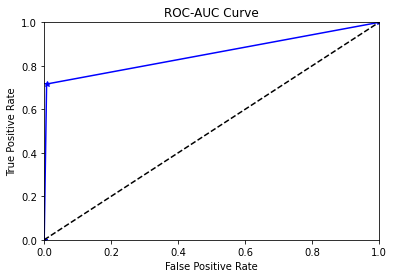

```python
from sklearn.metrics import roc_auc_score,roc_curve
fpr, tpr, thresholds = roc_curve(y_test, y_pred_tst)
roc_auc=roc_auc_score(y_test,y_pred_tst)
print('AUC score of Logistic Regression : %1.3f' %(roc_auc*100))
plt.plot(fpr, tpr, 'b*-',label='ROC curve for logistic (area = %0.2f)' % roc_auc)
plt.plot([0, 1], [0, 1], 'k--')
plt.xlim([0.0, 1.0])
plt.ylim([0.0, 1.0])
plt.xlabel('False Positive Rate')
plt.ylabel('True Positive Rate')
plt.title('ROC-AUC Curve');
```

- Accuracy score is high as It is more than 96% accuracy but target data is imbalanced, we need to consider the precision and recall here
- If we observed in classification report precision score is more(92%) but recall is low (72%) for who having loan on creditcard ,but for who doesnot have loan on credit card precision and recall are high
- This model is not good enough for predicting the loan having customers since false neagtive more(38)
- the f1 score observed as 81%
- The area under curve is observed as high (85%)

## Part 2.3 e - Balance the data using the right balancing technique.

### i. Check distribution of the target variable

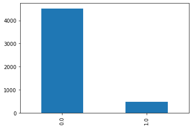

```python
dist=pd.DataFrame(Y.value_counts())
dist.plot(kind='bar',legend=None);
```

### ii. Say output is class A : 20% and class B : 80%

```python
print((Y.value_counts()/len(Y))*100)
```

```
0.0    90.4
1.0     9.6
Name: LoanOnCard, dtype: float64
```

- Class A (0.0) - 90.4%
- Class B (1.0) - 9.6%

### iii. Here you need to balance the target variable as 50:50.

- Here in this case I need to balance the data by using

  ```
           1) Under sampling
           2) Over sampling
  ```

- since my data size is less , I am considering the 'Over sampling' method to maintain balance and I dont want to lose the patterns in data set

```python
import imblearn
from imblearn.over_sampling import RandomOverSampler,SMOTENC,SMOTE
```

```
 the shape of y_train before balancing :
 0.0    3404
1.0     346
Name: LoanOnCard, dtype: int64


 the shape of y_train after balancing :
  0.0    3404
1.0    3404
Name: LoanOnCard, dtype: int64
```

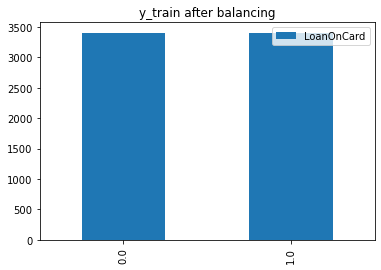

```python
# balancing target variable by Smote method

sm = SMOTE(random_state=1)
x_train_re,y_train_re=sm.fit_resample(x_train,y_train)
print(" the shape of y_train before balancing :\n" ,y_train.value_counts())
print(" \n \n the shape of y_train after balancing :\n " ,y_train_re.value_counts())
dis=pd.DataFrame(y_train_re.value_counts())
dis.plot(kind='bar')
plt.title('y_train after balancing');
```

```python
# implementing smote balancing on Logisticregression method

lgt_sm = LogisticRegression(max_iter = 5000)
lgt_sm.fit(x_train_re,np.ravel(y_train_re))
y_pred_tr_sm = lgt_sm.predict(x_train_re)
print("Training score : " , accuracy_score(y_train_re,y_pred_tr_sm))
y_pred_sm = lgt_sm.predict(x_test)
print("Testing score : " , accuracy_score(y_test,y_pred_sm))
print("\n Classification report : \n" , classification_report(y_test, y_pred_sm))

print("\n AUC score : \n " , roc_auc_score(y_test,y_pred_sm))
```

```
Training score :  0.9127497062279671
Testing score :  0.8864

 Classification report :
               precision    recall  f1-score   support

         0.0       0.98      0.89      0.93      1116
         1.0       0.48      0.84      0.61       134

    accuracy                           0.89      1250
   macro avg       0.73      0.86      0.77      1250
weighted avg       0.93      0.89      0.90      1250


 AUC score :
  0.8641470069009789
```

```
 the shape of y_train before balancing :
 0.0    3404
1.0     346
Name: LoanOnCard, dtype: int64


 the shape of y_train after balancing :
  0.0    3404
1.0    3404
Name: LoanOnCard, dtype: int64
```

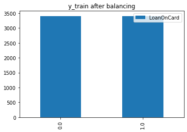

```python
# implementing Randomoversampling balancing on Logisticregression method

ovs = RandomOverSampler()
x_train_ro,y_train_ro = ovs.fit_resample(x_train,y_train)
print(" the shape of y_train before balancing :\n" ,y_train.value_counts())
print(" \n \n the shape of y_train after balancing :\n " ,y_train_ro.value_counts())
dis=pd.DataFrame(y_train_re.value_counts())
dis.plot(kind='bar');
plt.title('y_train after balancing');
```

```python
# implementing randomover balancing on Logisticregression method

lgt_RO = LogisticRegression(max_iter = 5000)
lgt_RO.fit(x_train_ro,np.ravel(y_train_ro))
y_pred_tr_ro = lgt_RO.predict(x_train_ro)
print("Training score : " , accuracy_score(y_train_ro,y_pred_tr_ro))
y_pred_resample = lgt_RO.predict(x_test)
print("Testing score :" , accuracy_score(y_test,y_pred_resample))
print("\n Classification report : \n " , classification_report(y_test, y_pred_resample, digits=2))
print("AUC score : \n " , roc_auc_score(y_test,y_pred_resample))
```

```
Training score :  0.8999706227967098
Testing score : 0.9008

 Classification report :
                precision    recall  f1-score   support

         0.0       0.99      0.90      0.94      1116
         1.0       0.52      0.91      0.66       134

    accuracy                           0.90      1250
   macro avg       0.75      0.91      0.80      1250
weighted avg       0.94      0.90      0.91      1250

AUC score :
  0.9050446691274808
```

```python
# implementing smotenc balancing on Logisticregression method

smnc = SMOTENC(categorical_features=True)
x_train_sm,y_train_sm=smnc.fit_resample(x_train,y_train)
lgt_smnc = LogisticRegression(max_iter = 5000)
lgt_smnc.fit(x_train_sm,np.ravel(y_train_sm))
y_pred_tr_smnc = lgt_smnc.predict(x_train_sm)
print("Training score : " , accuracy_score(y_train_sm,y_pred_tr_smnc))
y_pred_smnc = lgt_smnc.predict(x_test)
print(" Testing score : " , accuracy_score(y_test,y_pred_smnc))
print("\n classification report : \n " , classification_report(y_test, y_pred_smnc))
print(" AUC score : \n" , roc_auc_score(y_test,y_pred_smnc))
```

```
Training score :  0.913924794359577
 Testing score :  0.884

 classification report :
                precision    recall  f1-score   support

         0.0       0.98      0.89      0.93      1116
         1.0       0.48      0.83      0.60       134

    accuracy                           0.88      1250
   macro avg       0.73      0.86      0.77      1250
weighted avg       0.92      0.88      0.90      1250

 AUC score :
 0.8595196062697267
```

- Based on above data we are selecting RandomOverSample method to balance the Target Classes

```
 the shape of y_train before balancing :
 0.0    1116
1.0     134
Name: LoanOnCard, dtype: int64


 the shape of y_train after balancing :
  0.0    1116
1.0    1116
Name: LoanOnCard, dtype: int64
```

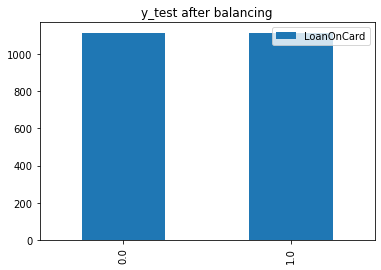

```python
ovs = RandomOverSampler()
x_test_ro,y_test_ro = ovs.fit_resample(x_test,y_test)
print(" the shape of y_train before balancing :\n" ,y_test.value_counts())
print(" \n \n the shape of y_train after balancing :\n " ,y_test_ro.value_counts())
dis_t=pd.DataFrame(y_test_ro.value_counts())
dis_t.plot(kind='bar');
plt.title('y_test after balancing');
```

## 2.3 f- Again train the same previous model on balanced data

```python
lgt_RO = LogisticRegression(max_iter = 5000)   # applying logistic regression on balancing data
lgt_RO.fit(x_train_ro,np.ravel(y_train_ro))
```

```
LogisticRegression(max_iter=5000)
```

## Part 2.3 g- Print evaluation metrics and clearly share differences observed

```python
y_pred_tr_ro = lgt_RO.predict(x_train_ro)
print('Training Score after Balancing Target classes : %1.3f' %accuracy_score(y_train_ro,y_pred_tr_ro))
y_pred_resample = lgt_RO.predict(x_test)
print('Testing Score after Balancing Target classes : %1.3f' %accuracy_score(y_test,y_pred_resample))
```

```
Training Score after Balancing Target classes : 0.900
Testing Score after Balancing Target classes : 0.901
```

```python
print("\n Classification report : \n " , classification_report(y_test, y_pred_resample))
```

```
 Classification report :
                precision    recall  f1-score   support

         0.0       0.99      0.90      0.94      1116
         1.0       0.52      0.91      0.66       134

    accuracy                           0.90      1250
   macro avg       0.75      0.91      0.80      1250
weighted avg       0.94      0.90      0.91      1250
```

```
 Confusion matrix :
```

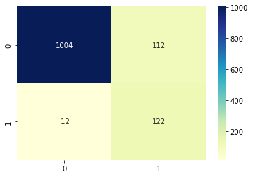

```python
print("\n Confusion matrix : \n ")
sns.heatmap(confusion_matrix(y_test,y_pred_resample),annot=True,fmt='3g',cmap='YlGnBu');
```

```python
# metrics of confusion metrics

cm= confusion_matrix(y_test,y_pred_resample)
TP=cm[1,1]
TN=cm[0,0]
FP=cm[0,1]
FN=cm[1,0]
print('True Positive : ' ,TP)
print('True Negative : ' ,TN)
print('False Positive : ' ,FP)
print('False Negative : ' ,FN)
```

```
True Positive :  122
True Negative :  1004
False Positive :  112
False Negative :  12
```

```python
from sklearn.metrics import precision_score,recall_score,f1_score
print('Precision score after balance %1.3f' %precision_score(y_test,y_pred_resample))
print('Recall score after balance %1.3f' %recall_score(y_test,y_pred_resample))
print('F1 score after balance  %1.3f' %f1_score(y_test,y_pred_resample))
```

```
Precision score after balance 0.521
Recall score after balance 0.910
F1 score after balance  0.663
```

```
AUC Score before balance the data :  85.462
AUC Score after balance the data  : 90.504
```

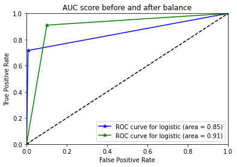

```python
from sklearn.metrics import roc_auc_score,roc_curve
fpr, tpr, thresholds = roc_curve(y_test, y_pred_tst)
fpr1, tpr1, thresholds1 = roc_curve(y_test, y_pred_resample)
roc_auc1=roc_auc_score(y_test,y_pred_tst)
roc_auc2=roc_auc_score(y_test,y_pred_resample)
print('AUC Score before balance the data :  %1.3f' %(roc_auc1*100))
print('AUC Score after balance the data  : %1.3f' %(roc_auc2*100))
plt.plot(fpr, tpr,'b*-', label='ROC curve for logistic (area = %0.2f)' % roc_auc1)
plt.plot(fpr1, tpr1,'g*-', label='ROC curve for logistic (area = %0.2f)' % roc_auc2)
plt.plot([0, 1], [0, 1], 'k--')
plt.xlim([0.0, 1.0])
plt.ylim([0.0, 1.0])
plt.xlabel('False Positive Rate')
plt.ylabel('True Positive Rate')
plt.title('AUC score before and after balance')
plt.legend();
```

- I want to know how my model was performing on balanced testing data.
- for balanced testing set data will be

```python
y_pred_bal_tst = lgt_RO.predict(x_test_ro)
print('Testing Score after Balancing Target classes : %1.3f' %accuracy_score(y_test_ro,y_pred_bal_tst))
print(classification_report(y_test_ro,y_pred_bal_tst))
print("AUC Score " , roc_auc_score(y_test_ro,y_pred_bal_tst))
```

```
Testing Score after Balancing Target classes : 0.904
              precision    recall  f1-score   support

         0.0       0.91      0.90      0.90      1116
         1.0       0.90      0.91      0.90      1116

    accuracy                           0.90      2232
   macro avg       0.90      0.90      0.90      2232
weighted avg       0.90      0.90      0.90      2232

AUC Score  0.9041218637992832
```

#### The difference between imbalanced model and balanced model of Logisticregression

- After balancing the Target classes our model

  ```
    1) Accuracy decreased from 96% to 90%
    2) precision decreased from 92% to 90%
    3) Recall score Increased from 72% to 91 %
    4) f1 score Increased from 81% to 90 %
    5) AUC score increased from 85% to 90%
  ```

- After balancing the Target classes our model performance is increased

## Part 2.4 a- Train a base model each for SVM, KNN

## Part 2.4 b - Tune parameters for each of the models wherever required and finalize a mode

```python
# importing necessary libraries

import sklearn.svm
from sklearn.svm import SVC
```

##### Training KNN base model

```python
knn_1 = KNeighborsClassifier()
knn_1.fit(x_train_ro,y_train_ro) # fitting random over sample
y_pred_knn = knn_1.predict(x_test)
print('KNN training score : %1.3f'%knn_1.score(x_train_ro,y_train_ro))
print('KNN testing score : %1.3f'%accuracy_score(y_test,y_pred_knn))
print(classification_report(y_test,y_pred_knn))
print("AUC score : " ,roc_auc_score(y_test,y_pred_knn))
```

```
KNN training score : 0.957
KNN testing score : 0.854
              precision    recall  f1-score   support

         0.0       0.96      0.87      0.91      1116
         1.0       0.40      0.69      0.50       134

    accuracy                           0.85      1250
   macro avg       0.68      0.78      0.71      1250
weighted avg       0.90      0.85      0.87      1250

AUC score :  0.7833948536885464
```

```python
y_pred_bal_knn = knn_1.predict(x_test_ro)
print("Classification report for knn base model : \n " , classification_report(y_test_ro,y_pred_bal_knn))   # classification report for balanced test set
print("\n AUC score : " , roc_auc_score(y_test_ro,y_pred_bal_knn))
```

```
Classification report for knn base model :
                precision    recall  f1-score   support

         0.0       0.73      0.87      0.80      1116
         1.0       0.84      0.68      0.75      1116

    accuracy                           0.78      2232
   macro avg       0.79      0.78      0.78      2232
weighted avg       0.79      0.78      0.78      2232


 AUC score :  0.7773297491039426
```

n_neighbour parameter search

```python
k_values = np.arange(1,50)
ac_scores = []
for k in k_values:
    knn_2 = KNeighborsClassifier(n_neighbors=k)
    knn_2.fit(x_train_ro,y_train_ro)
    y_hat = knn_2.predict(x_test)
    score = accuracy_score(y_test,y_hat)
    ac_scores.append(score)
MSE = [1 - x for x in ac_scores]

# determining best k
optimal_k = k_values[MSE.index(min(MSE))]
print("The optimal number of neighbors is %d" % optimal_k)
```

```
The optimal number of neighbors is 1
```

```python
knn_3 = KNeighborsClassifier(n_neighbors=optimal_k)
knn_3.fit(x_train_ro,y_train_ro) # fitting random over sample
y_pred_knn1 = knn_3.predict(x_test)
print('KNN training score when k = 1  : %1.3f'%knn_3.score(x_train_ro,y_train_ro))
print('knn accuracy score when k = 1 : %1.3f'%accuracy_score(y_test,y_pred_knn1))
print("\n Clasification report : \n " ,classification_report(y_test,y_pred_knn1))
print("AUC SCORE : " ,roc_auc_score(y_test,y_pred_knn1))
```

```
KNN training score when k = 1  : 1.000
knn accuracy score when k = 1 : 0.878

 Clasification report :
                precision    recall  f1-score   support

         0.0       0.93      0.94      0.93      1116
         1.0       0.42      0.37      0.40       134

    accuracy                           0.88      1250
   macro avg       0.67      0.66      0.66      1250
weighted avg       0.87      0.88      0.87      1250

AUC SCORE :  0.6556531856844808
```

for optimal p value

```python
p_values = np.arange(1,6)
ac_scores = []
for p in p_values:
    knn_3 = KNeighborsClassifier(n_neighbors=1,p=p)
    knn_3.fit(x_train_ro,y_train_ro)
    y_hat = knn_2.predict(x_test)
    score = accuracy_score(y_test,y_hat)
    ac_scores.append(score)
MSE = [1 - x for x in ac_scores]

# determining best p
optimal_p = p_values[MSE.index(min(MSE))]
print("The optimal p values is %d" % optimal_p)
```

```
The optimal p values is 1
```

```python
knn_4 = KNeighborsClassifier(p=optimal_p)
knn_4.fit(x_train_ro,y_train_ro)
y_pred_knn2 = knn_4.predict(x_test)
print('KNN training score when p = 1  : %1.3f'%knn_4.score(x_train_ro,y_train_ro))
print('knn accuracy score when p = 1 : %1.3f'%accuracy_score(y_test,y_pred_knn2))
print(" \n Classification report : \n " , classification_report(y_test,y_pred_knn2))
print("AUC SCORE : " ,roc_auc_score(y_test,y_pred_knn2))
```

```
KNN training score when p = 1  : 0.965
knn accuracy score when p = 1 : 0.882

 Classification report :
                precision    recall  f1-score   support

         0.0       0.96      0.90      0.93      1116
         1.0       0.47      0.72      0.56       134

    accuracy                           0.88      1250
   macro avg       0.71      0.81      0.75      1250
weighted avg       0.91      0.88      0.89      1250

AUC SCORE :  0.8089258011020167
```

for optimal algoritham

```python
algr  = ['auto', 'ball_tree', 'kd_tree', 'brute']
ac_scores = []
for p in algr:
    knn_3 = KNeighborsClassifier(algorithm=p)
    knn_3.fit(x_train_ro,y_train_ro)
    y_hat = knn_2.predict(x_test)
    score = accuracy_score(y_test,y_hat)
    ac_scores.append(score)
MSE = [1 - x for x in ac_scores]

# determining best p
optimal_p = algr[MSE.index(min(MSE))]
print("The optimal algoritham  is : " ,optimal_p)
```

```
The optimal algoritham  is :  auto
```

- when we change the value of 'p'(minikowski) we got good accuracy and Area under curve score improved
- our model as

```python
knn_fin = KNeighborsClassifier(p=1)
knn_fin.fit(x_train_ro,y_train_ro) # fitting random over sample
y_pred_knn2 = knn_fin.predict(x_test)
print('knn accuracy score when p = 1 : %1.3f'%accuracy_score(y_test,y_pred_knn2))
print("\n Classification model : \n " , classification_report(y_test,y_pred_knn2))
print("AUC SCORE : " ,roc_auc_score(y_test,y_pred_knn2))
```

```
knn accuracy score when p = 1 : 0.882

 Classification model :
                precision    recall  f1-score   support

         0.0       0.96      0.90      0.93      1116
         1.0       0.47      0.72      0.56       134

    accuracy                           0.88      1250
   macro avg       0.71      0.81      0.75      1250
weighted avg       0.91      0.88      0.89      1250

AUC SCORE :  0.8089258011020167
```

Checking classification report on balancing dataset for KNN model

```python
y_pred_bal_knn_fin = knn_fin.predict(x_test_ro)
print("\n Classifiaction report : \n " , classification_report(y_test_ro,y_pred_bal_knn_fin))   # classification report for balanced test set
print("\n AUC score : " , roc_auc_score(y_test_ro,y_pred_bal_knn_fin))
```

```
 Classifiaction report :
                precision    recall  f1-score   support

         0.0       0.75      0.90      0.82      1116
         1.0       0.88      0.71      0.78      1116

    accuracy                           0.80      2232
   macro avg       0.82      0.80      0.80      2232
weighted avg       0.82      0.80      0.80      2232


 AUC score :  0.8037634408602151
```

##### Training SVM base model

```
svm training score : 0.874
svm testing score : 0.838

 classification report :
                precision    recall  f1-score   support

         0.0       0.99      0.83      0.90      1116
         1.0       0.39      0.93      0.55       134

    accuracy                           0.84      1250
   macro avg       0.69      0.88      0.73      1250
weighted avg       0.93      0.84      0.86      1250

AUC score  0.8762170331139998
```

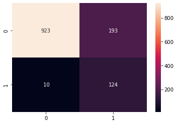

```python
svm_base = SVC()
svm_base.fit(x_train_ro,y_train_ro)
print("svm training score : %1.3f" %svm_base.score(x_train_ro,y_train_ro))
print("svm testing score : %1.3f" %svm_base.score(x_test,y_test))
y_hat_base = svm_base.predict(x_test)
print('\n classification report : \n ' , classification_report(y_test,y_hat_base))
print('AUC score ' , roc_auc_score(y_test,y_hat_base))
sns.heatmap(confusion_matrix(y_test,y_hat_base),annot=True,fmt='3g');
```

```python
y_hat_bal_base = svm_base.predict(x_test_ro)
print('classification report : \n ' , classification_report(y_test_ro,y_hat_bal_base)) #classification report for balanced testing set
```

```
classification report :
                precision    recall  f1-score   support

         0.0       0.92      0.83      0.87      1116
         1.0       0.84      0.93      0.89      1116

    accuracy                           0.88      2232
   macro avg       0.88      0.88      0.88      2232
weighted avg       0.88      0.88      0.88      2232
```

Checking for optimal kernal

```python
kern  = ['linear', 'poly', 'rbf', 'sigmoid']
ac_scores = []
for k in kern:
    svm_1 = SVC(kernel=k,verbose=1)
    svm_1.fit(x_train_ro,y_train_ro)
    y_hat = svm_1.predict(x_test)
    score = accuracy_score(y_test,y_hat)
    ac_scores.append(score)
MSE = [1 - x for x in ac_scores]

# determining best p
optimal_kern = kern[MSE.index(min(MSE))]
print("The optimal kernal  is : " ,optimal_kern)
```

```
[LibSVM][LibSVM][LibSVM][LibSVM]The optimal kernal  is :  linear
```

```python
gamma = ['scale', 'auto']
ac_scores = []
for g in gamma :
    svm_2 = SVC(gamma=g,verbose=1)
    svm_2.fit(x_train_ro,y_train_ro)
    y_hat = svm_2.predict(x_test)
    score = accuracy_score(y_test,y_hat)
    ac_scores.append(score)
MSE = [1 - x for x in ac_scores]

# determining best p
optimal_gam = gamma[MSE.index(min(MSE))]
print("The optimal gamma  is : " ,optimal_gam)
```

```
[LibSVM][LibSVM]The optimal gamma  is :  auto
```

```python
svm_final = SVC(C=1,kernel = 'linear')
svm_final.fit(x_train_ro,y_train_ro)
print("Training score : " , svm_final.score(x_train_ro,y_train_ro))
print("Testing score : " , svm_final.score(x_test,y_test))
y_pred_svm = svm_final.predict(x_test)
print("\n Classification report : \n" ,classification_report(y_test,y_pred_svm))
print("AUC Score :" , roc_auc_score(y_test,y_pred_svm))
```

```
Training score :  0.9048178613396005
Testing score :  0.9104

 Classification report :
               precision    recall  f1-score   support

         0.0       0.99      0.91      0.95      1116
         1.0       0.55      0.92      0.69       134

    accuracy                           0.91      1250
   macro avg       0.77      0.91      0.82      1250
weighted avg       0.94      0.91      0.92      1250

AUC Score : 0.9137043278232493
```

```python
y_pred_bal_svm = svm_final.predict(x_test_ro)         # for balanced test set
print("\n Classification report : \n " , classification_report(y_test_ro,y_pred_bal_svm))
print("AUC Score : " , roc_auc_score(y_test_ro,y_pred_bal_svm))
```

```
 Classification report :
                precision    recall  f1-score   support

         0.0       0.92      0.91      0.91      1116
         1.0       0.91      0.92      0.92      1116

    accuracy                           0.92      2232
   macro avg       0.92      0.92      0.92      2232
weighted avg       0.92      0.92      0.92      2232

AUC Score :  0.9153225806451613
```

```python
# checking for other regularization parameter values

svm_C_2 = SVC(C=2,kernel = 'linear')
svm_C_2.fit(x_train_ro,y_train_ro)
print(svm_C_2.score(x_train_ro,y_train_ro))
print(svm_C_2.score(x_test,y_test))
y_predictor = svm_C_2.predict(x_test)
print(classification_report(y_test,y_predictor))
print(roc_auc_score(y_test,y_predictor))
```

```
0.9032021151586369
0.9048
              precision    recall  f1-score   support

         0.0       0.99      0.90      0.94      1116
         1.0       0.53      0.91      0.67       134

    accuracy                           0.90      1250
   macro avg       0.76      0.91      0.81      1250
weighted avg       0.94      0.90      0.92      1250

0.9072848124966565
```

```python
# checking for other regularization parameter values

svm_C_5 = SVC(C=5,kernel = 'linear')
svm_C_5.fit(x_train_ro,y_train_ro)
print(svm_C_5.score(x_train_ro,y_train_ro))
print(svm_C_5.score(x_test,y_test))
y_predictor = svm_C_5.predict(x_test)
print(classification_report(y_test,y_predictor))
print(roc_auc_score(y_test,y_predictor))
```

```
0.906433607520564
0.8952
              precision    recall  f1-score   support

         0.0       0.99      0.89      0.94      1116
         1.0       0.51      0.93      0.65       134

    accuracy                           0.90      1250
   macro avg       0.75      0.91      0.80      1250
weighted avg       0.94      0.90      0.91      1250

0.9084750976301288
```

### Finalize A model

```
AUC Score for LogisticRegression model:  90.412
AUC Score for KNN model:                 80.376
AUC Score for SVM model:                 91.532
```

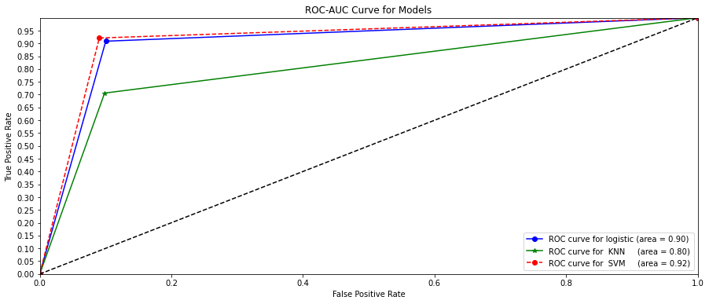

```python
plt.figure(figsize=(15,6))
fpr_lgt, tpr_lgt, thresholds_lgt = roc_curve(y_test_ro, y_pred_bal_tst)
fpr_knn, tpr_knn, thresholds_knn = roc_curve(y_test_ro,y_pred_bal_knn_fin)
fpr_svm, tpr_svm, thresholds_svm = roc_curve(y_test_ro,y_pred_bal_svm)
roc_auc_lgt=roc_auc_score(y_test_ro,y_pred_bal_tst)
roc_auc_knn=roc_auc_score(y_test_ro,y_pred_bal_knn_fin)
roc_auc_svm=roc_auc_score(y_test_ro,y_pred_bal_svm)
print('AUC Score for LogisticRegression model:  %1.3f' %(roc_auc_lgt*100))
print('AUC Score for KNN model:                 %1.3f' %(roc_auc_knn*100))
print('AUC Score for SVM model:                 %1.3f' %(roc_auc_svm*100))
plt.plot(fpr_lgt, tpr_lgt,'bo-', label=('ROC curve for logistic (area = %0.2f)' % roc_auc_lgt))
plt.plot(fpr_knn, tpr_knn,'g*-', label='ROC curve for  KNN     (area = %0.2f)' % roc_auc_knn)
plt.plot(fpr_svm, tpr_svm,'ro--', label='ROC curve for  SVM     (area = %0.2f)' % roc_auc_svm)
plt.plot([0, 1], [0, 1], 'k--')
plt.xlim([0.0, 1.0])
plt.ylim([0.0, 1.0])
plt.yticks(np.arange(0, 1, step=0.05))
plt.xlabel('False Positive Rate')
plt.ylabel('True Positive Rate')
plt.title('ROC-AUC Curve for Models')
plt.legend();
```

- Both LogisticRegression and SVM both models are Good for this classification.
- when compared with KNN Model ,SVM model has more improvement in accuracy and AUC scores.
- I am considering the SVM as Best model.

## Part 2.4 c- Print evaluation metrics for final mode

```
Training accuracy score for SVM :  0.905
Testing accuracy score for SVM  :  0.915


 Classification report for SVM

               precision    recall  f1-score   support

         0.0       0.92      0.91      0.91      1116
         1.0       0.91      0.92      0.92      1116

    accuracy                           0.92      2232
   macro avg       0.92      0.92      0.92      2232
weighted avg       0.92      0.92      0.92      2232



 Confusion matrix for SVM
```

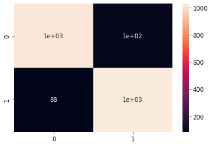

```python
# Evalution metrics

print('Training accuracy score for SVM :  %1.3f' %svm_final.score(x_train_ro,y_train_ro))
print('Testing accuracy score for SVM  :  %1.3f' %svm_final.score(x_test_ro,y_test_ro))

#confusion matrix and classification report


print('\n \n Classification report for SVM \n \n' , classification_report(y_test_ro,y_pred_bal_svm))

print('\n \n Confusion matrix for SVM \n \n ')

sns.heatmap(confusion_matrix(y_test_ro,y_pred_bal_svm),annot=True);
```

```
AUC Score for SVM model:                 91.532
```

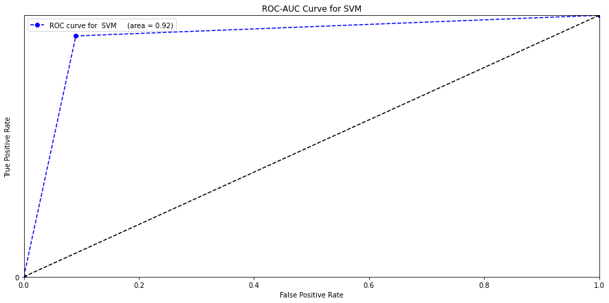

```python
fpr_svm, tpr_svm, thresholds_svm = roc_curve(y_test_ro,y_pred_bal_svm)
roc_auc_svm=roc_auc_score(y_test_ro,y_pred_bal_svm)
print('AUC Score for SVM model:                 %1.3f' %(roc_auc_svm*100))
plt.figure(figsize=(15,7))
plt.plot(fpr_svm, tpr_svm,'bo--', label='ROC curve for  SVM     (area = %0.2f)' % roc_auc_svm)
plt.plot([0, 1], [0, 1], 'k--')
plt.xlim([0.0, 1.0])
plt.ylim([0.0, 1.0])
plt.yticks(np.arange(0, 1))
plt.xlabel('False Positive Rate')
plt.ylabel('True Positive Rate')
plt.title('ROC-AUC Curve for SVM')
plt.legend();
```

## Part 2.4 d- Share improvement achieved from base model to final model

```
svm training score for base model: 0.874
svm testing score for base model : 0.879


 classification report for base model svm :
                precision    recall  f1-score   support

         0.0       0.92      0.83      0.87      1116
         1.0       0.84      0.93      0.89      1116

    accuracy                           0.88      2232
   macro avg       0.88      0.88      0.88      2232
weighted avg       0.88      0.88      0.88      2232



 AUC score for base model svm :  0.8790322580645161
```

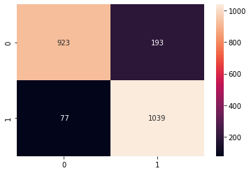

```python
print("svm training score for base model: %1.3f"       %svm_base.score(x_train_ro,y_train_ro))
print("svm testing score for base model : %1.3f"       %svm_base.score(x_test_ro,y_test_ro))
print('\n \n classification report for base model svm : \n ', classification_report(y_test_ro,y_hat_bal_base))
print(' \n \n AUC score for base model svm : ' ,              roc_auc_score(y_test_ro,y_hat_bal_base))
sns.heatmap(confusion_matrix(y_test_ro,y_hat_bal_base),annot=True,fmt='3g');
```

```
svm training score for final model: 0.905
svm testing score for final model : 0.915


 classification report for final model svm :
                precision    recall  f1-score   support

         0.0       0.92      0.91      0.91      1116
         1.0       0.91      0.92      0.92      1116

    accuracy                           0.92      2232
   macro avg       0.92      0.92      0.92      2232
weighted avg       0.92      0.92      0.92      2232



 AUC score for final model svm :
  0.9153225806451613
```

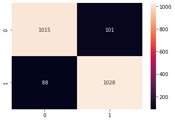

```python
print("svm training score for final model: %1.3f"       %svm_final.score(x_train_ro,y_train_ro))
print("svm testing score for final model : %1.3f"       %svm_final.score(x_test_ro,y_test_ro))
print('\n \n classification report for final model svm : \n ', classification_report(y_test_ro,y_pred_bal_svm))
print('\n \n AUC score for final model svm : \n ' ,              roc_auc_score(y_test_ro,y_pred_bal_svm))
sns.heatmap(confusion_matrix(y_test_ro,y_pred_bal_svm),annot=True,fmt='3g');
```

- when I am considering class B(1.0) i.e. The customers who having loan on card - Improvements from base SVM model to final SVM model by Class B (1.0) 1)Acuuracy improved by 4% 2)Precision improved by 7% 3)Recall little decrement by 1% 4)f1 score improved by 3% - Improvements from base SVM model to final SVM model by over all performance (+4%) 1)Acuuracy improved by 4% 2)Precision improved by 4% 3)Recall improved by 4% 4)f1 score improved by 4% 5)AUC score improved by 4%